# PCIT-CoS-Waitlist RCT Paper 1: MM Attuned

Nancy Briggs

2024-04-23

### MM Attuned

Output run on 2024-04-23

Variables: MM_attuned, T2_attuned, T3_attuned

#### Descriptives

| group | time | n | mean | sd | median | min | max |
| --- | --- | --- | --- | --- | --- | --- | --- |
| 1 | 1 | 30 | 18.500 | 13.559 | 17.5 | 1 | 67 |
| 1 | 2 | 23 | 22.261 | 14.738 | 19.0 | 1 | 53 |
| 1 | 3 | 13 | 13.462 | 8.491 | 13.0 | 1 | 25 |
| 2 | 1 | 28 | 17.679 | 7.949 | 17.5 | 2 | 34 |
| 2 | 2 | 12 | 24.667 | 10.840 | 26.0 | 3 | 41 |
| 2 | 3 | 3 | 17.333 | 13.650 | 15.0 | 5 | 32 |
| 3 | 1 | 30 | 20.233 | 13.612 | 17.5 | 0 | 54 |
| 3 | 2 | 26 | 21.692 | 15.197 | 22.0 | 2 | 72 |
| 3 | 3 | 1 | 29.000 | NA | 29.0 | 29 | 29 |

There is 1 G3 observation with data. Here is the table having recoded that value to missing.

| group | time | n | mean | sd | median | min | max |
| --- | --- | --- | --- | --- | --- | --- | --- |
| 1 | 1 | 30 | 18.500 | 13.559 | 17.5 | 1 | 67 |
| 1 | 2 | 23 | 22.261 | 14.738 | 19.0 | 1 | 53 |
| 1 | 3 | 13 | 13.462 | 8.491 | 13.0 | 1 | 25 |
| 2 | 1 | 28 | 17.679 | 7.949 | 17.5 | 2 | 34 |
| 2 | 2 | 12 | 24.667 | 10.840 | 26.0 | 3 | 41 |
| 2 | 3 | 3 | 17.333 | 13.650 | 15.0 | 5 | 32 |
| 3 | 1 | 30 | 20.233 | 13.612 | 17.5 | 0 | 54 |
| 3 | 2 | 26 | 21.692 | 15.197 | 22.0 | 2 | 72 |
| 3 | 3 | 0 | NaN | NA | NA | Inf | -Inf |

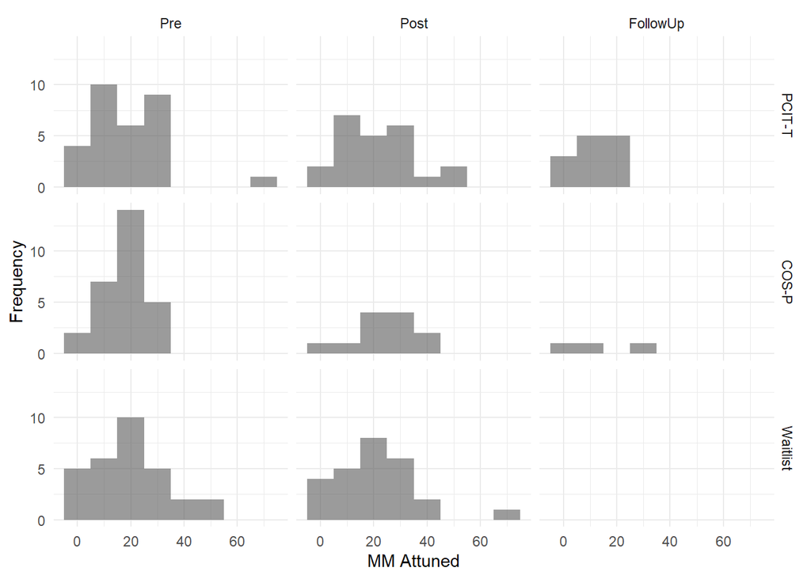

#### Model & Results

A linear mixed model with random effect for individual and fixed effects of group, time and the interaction was run. Estimated marginal means were obtained, and contrasts specified to test Hypothesis 1 and Hypothesis 2.

```
## fixed-effect model matrix is rank deficient so dropping 1 column / coefficient
```

```
## refitting model(s) with ML (instead of REML)
```

|  | Effect | npar | AIC | BIC | logLik | deviance | Chisq | Df | Pr(>Chisq) |
| --- | --- | --- | --- | --- | --- | --- | --- | --- | --- |
| result0 | Intercept | 3 | 1287.493 | 1296.811 | -640.746 | 1281.493 | NA | NA | NA |
| result1 | Group | 5 | 1291.008 | 1306.538 | -640.504 | 1281.008 | 0.485 | 2 | 0.785 |
| result2 | Time | 7 | 1283.844 | 1305.586 | -634.922 | 1269.844 | 11.164 | 2 | 0.004 |
| result3 | Group*Time | 10 | 1287.502 | 1318.562 | -633.751 | 1267.502 | 2.342 | 3 | 0.505 |

This is the ANOVA table for the model. p-values are likelihood ratio tests for adding the new term to the model just before. A p-value <0.05 indicates that adding that term results in better model fit. The most important p-value is the interaction p-value. Here, there is no evidence that the pattern of change over time is different among the groups (p=0.505).

```r
summary(result3)
```

```
## Linear mixed model fit by REML. t-tests use Satterthwaite's method [
## lmerModLmerTest]
## Formula: outcome ~ group * time + (1 | id)
##    Data: dat
##
## REML criterion at convergence: 1237.1
##
## Scaled residuals:
##     Min      1Q  Median      3Q     Max
## -1.4736 -0.5548 -0.0552  0.4876  3.5335
##
## Random effects:
##  Groups   Name        Variance Std.Dev.
##  id       (Intercept) 84.16    9.174
##  Residual             73.76    8.589
## Number of obs: 165, groups:  id, 88
##
## Fixed effects:
##              Estimate Std. Error       df t value Pr(>|t|)
## (Intercept)   18.5000     2.2944 126.1852   8.063 4.91e-13 ***
## group2        -0.8214     3.3021 126.1852  -0.249   0.8040
## group3         1.7333     3.2447 126.1852   0.534   0.5941
## time2          4.1664     2.4626  86.3279   1.692   0.0943 .
## time3         -5.0341     3.0642  90.4690  -1.643   0.1039
## group2:time2   2.5172     4.0887  94.4652   0.616   0.5396
## group3:time2  -2.7675     3.4003  84.7945  -0.814   0.4180
## group2:time3   5.1666     6.7003  96.9402   0.771   0.4425
## ---
## Signif. codes:  0 '***' 0.001 '**' 0.01 '*' 0.05 '.' 0.1 ' ' 1
##
## Correlation of Fixed Effects:
##             (Intr) group2 group3 time2  time3  grp2:2 grp3:2
## group2      -0.695
## group3      -0.707  0.491
## time2       -0.435  0.302  0.308
## time3       -0.350  0.243  0.247  0.379
## group2:tim2  0.262 -0.377 -0.185 -0.602 -0.228
## group3:tim2  0.315 -0.219 -0.446 -0.724 -0.274  0.436
## group2:tim3  0.160 -0.230 -0.113 -0.173 -0.457  0.269  0.125
## fit warnings:
## fixed-effect model matrix is rank deficient so dropping 1 column / coefficient
```

#### Estimated Means & Change

Estimated means for each Treatment and Time are presented. In addition, within-group change between time points is presented with 95% CIs.

##### Group mean difference at each timepoint

NOTE THIS SET OF RESULTS DOES NOT BOOTSTRAP.

Group Differences at Each Time Point

| Group Difference | Time | Mean | SE | t | p | adj p | Lower CL | Upper CL | Effect Size | Lower CL | Upper CL |
| --- | --- | --- | --- | --- | --- | --- | --- | --- | --- | --- | --- |
| 1 - 2 | 1 | 0.821 | 3.302 | 0.249 | 0.966 | 1 | -7.013 | 8.656 | 0.073 | -0.222 | 0.562 |
| 1 - 3 | 1 | -1.733 | 3.245 | -0.534 | 0.855 | 1 | -9.432 | 5.965 | -0.155 | -0.486 | 0.195 |
| 2 - 3 | 1 | -2.555 | 3.302 | -0.774 | 0.720 | 1 | -10.389 | 5.280 | -0.228 | -0.751 | 0.195 |
| 1 - 2 | 2 | -1.696 | 4.191 | -0.405 | 0.914 | 1 | -11.614 | 8.222 | -0.151 | -0.693 | 0.199 |
| 1 - 3 | 2 | 1.034 | 3.506 | 0.295 | 0.953 | 1 | -7.272 | 9.340 | 0.092 | -0.206 | 0.225 |
| 2 - 3 | 2 | 2.730 | 4.121 | 0.662 | 0.786 | 1 | -7.024 | 12.484 | 0.244 | -0.106 | 0.845 |
| 1 - 2 | 3 | -4.345 | 6.789 | -0.640 | 0.798 | 1 | -20.443 | 11.753 | -0.388 | -0.835 | 0.233 |
| 1 - 3 | 3 | NA | NA | NA | NA | NA | NA | NA | NA | NA | NA |
| 2 - 3 | 3 | NA | NA | NA | NA | NA | NA | NA | NA | NA | NA |

##### Change within each group

Within-Group Change and Effect Sizes

| Change | Group | Mean | SE | t | p | adj p | Lower CL | Upper CL | Effect Size | Lower CL | Upper CL |
| --- | --- | --- | --- | --- | --- | --- | --- | --- | --- | --- | --- |
| 1 - 2 | 1 | -4.166 | 2.467 | -1.689 | 0.216 | 0.285 | -10.058 | 1.725 | -0.372 | -0.546 | -0.008 |
| 1 - 3 | 1 | 5.034 | 3.075 | 1.637 | 0.236 | 0.316 | -2.301 | 12.369 | 0.449 | 0.086 | 0.503 |
| 2 - 3 | 1 | 9.200 | 3.127 | 2.942 | 0.012 | 0.013 | 1.731 | 16.669 | 0.821 | 0.405 | 0.981 |
| 1 - 2 | 2 | -6.684 | 3.280 | -2.038 | 0.109 | 0.133 | -14.495 | 1.128 | -0.596 | -0.921 | -0.346 |
| 1 - 3 | 2 | -0.132 | 5.993 | -0.022 | 1.000 | 1.000 | -14.407 | 14.142 | -0.012 | -1.035 | 0.479 |
| 2 - 3 | 2 | 6.551 | 6.120 | 1.070 | 0.535 | 0.862 | -8.045 | 21.147 | 0.584 | -0.152 | 1.160 |
| 1 - 2 | 3 | -1.399 | 2.347 | -0.596 | 0.823 | 1.000 | -7.008 | 4.210 | -0.125 | -0.436 | 0.260 |
| 1 - 3 | 3 | NA | NA | NA | NA | NA | NA | NA | NA | NA | NA |
| 2 - 3 | 3 | NA | NA | NA | NA | NA | NA | NA | NA | NA | NA |

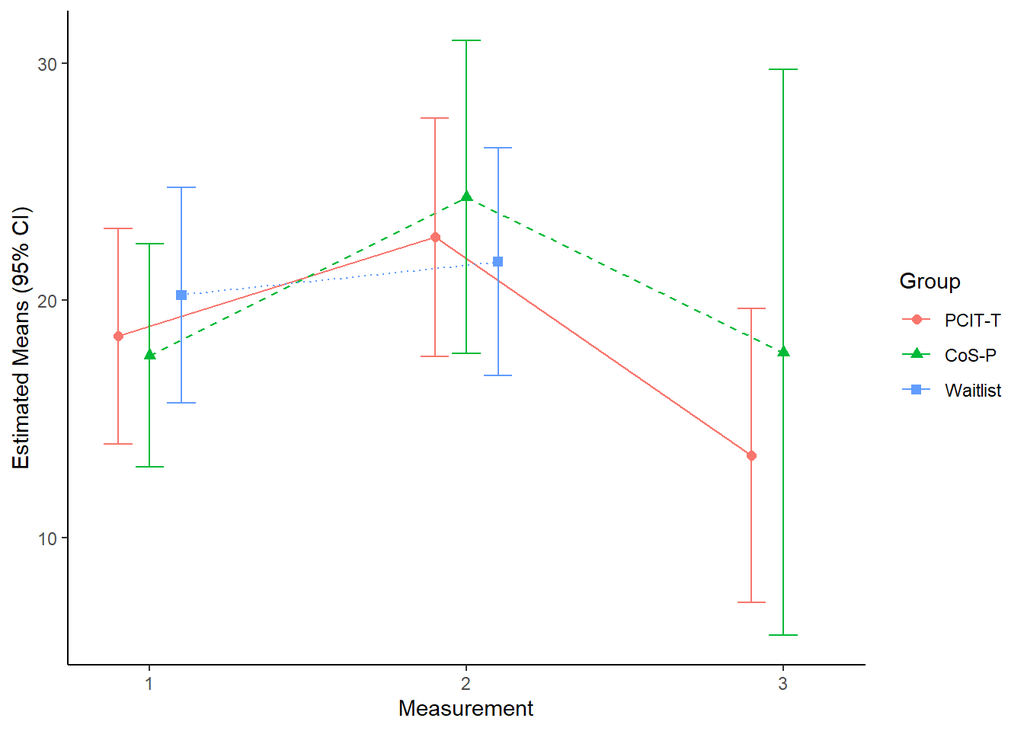

#### Hypothesis 1

We hypothesize that from baseline (‘T1’) to post-treatment/waitlist (‘T2’) there will be a gradient effect, whereby parent-child dyads who receive PCIT-T will show the greatest gains and parent-child dyads who receive no treatment will show the least gains. For the outcome, then, the null hypothesis is:

$H_0: \text {mean change}(\text{PCIT-T}) = \text {mean change}(\text{CoS-P}) = \text {mean change}(\text{Waitlist})$ $H_A: \text {mean change}(\text{PCIT-T}) > \text {mean change}(\text{CoS-P}) > \text {mean change}(\text{Waitlist})$

This is a joint hypothesis test.

First, confirming that the ordering of the means is as hypothesized:

```
## group = 1:
##  contrast estimate   SE   df t.ratio p.value
##  1 - 2      -4.166 2.47 80.6  -1.689  0.2157
##  1 - 3       5.034 3.07 84.8   1.637  0.2357
##  2 - 3       9.200 3.13 79.7   2.942  0.0118
##
## group = 2:
##  contrast estimate   SE   df t.ratio p.value
##  1 - 2      -6.684 3.28 93.9  -2.038  0.1089
##  1 - 3      -0.132 5.99 93.2  -0.022  0.9997
##  2 - 3       6.551 6.12 86.1   1.070  0.5349
##
## group = 3:
##  contrast estimate   SE   df t.ratio p.value
##  1 - 2      -1.399 2.35 77.4  -0.596  0.8227
##  1 - 3      nonEst   NA   NA      NA      NA
##  2 - 3      nonEst   NA   NA      NA      NA
##
## Degrees-of-freedom method: kenward-roger
## P value adjustment: tukey method for comparing a family of 3 estimates
```

```
##   (Intercept) group2 group3 time2 time3 group2:time2 group3:time2 group2:time3
## 1           0      0      0     0     0           -1            0            0
## 2           0      0      0     0     1            0            1            0
```

```
##
##   General Linear Hypotheses
##
## Linear Hypotheses:
##        Estimate
## 1 == 0   -2.517
## 2 == 0   -7.802
##
## Global Test:
##       F DF1 DF2  Pr(>F)
## 1 2.537   2 155 0.08242
```

#### Hypothesis 2

##### Change from T2-T3

There will be a gradient of size of change from T2 to T3 such that the change in the PCIT-T group > the change in the CoS-P group. This isn’t really a gradient; it’s just 1 hypothesis.

First, the change in PCITT and COSP from time 2 to time 3:

```
## group = 1:
##  time emmean   SE  df lower.CL upper.CL
##  1      18.5 2.29 122    13.96     23.0
##  2      22.7 2.54 141    17.65     27.7
##  3      13.5 3.13 156     7.28     19.6
##
## group = 2:
##  time emmean   SE  df lower.CL upper.CL
##  1      17.7 2.37 122    12.98     22.4
##  2      24.4 3.34 157    17.77     31.0
##  3      17.8 6.02 118     5.88     29.7
##
## group = 3:
##  time emmean   SE  df lower.CL upper.CL
##  1      20.2 2.29 122    15.69     24.8
##  2      21.6 2.42 133    16.85     26.4
##  3    nonEst   NA  NA       NA       NA
##
## Degrees-of-freedom method: kenward-roger
## Confidence level used: 0.95
```

```
## group = 1:
##  contrast estimate   SE   df lower.CL upper.CL
##  1 - 2      -4.166 2.47 80.6   -10.06     1.72
##  1 - 3       5.034 3.07 84.8    -2.30    12.37
##  2 - 3       9.200 3.13 79.7     1.73    16.67
##
## group = 2:
##  contrast estimate   SE   df lower.CL upper.CL
##  1 - 2      -6.684 3.28 93.9   -14.50     1.13
##  1 - 3      -0.132 5.99 93.2   -14.41    14.14
##  2 - 3       6.551 6.12 86.1    -8.04    21.15
##
## group = 3:
##  contrast estimate   SE   df lower.CL upper.CL
##  1 - 2      -1.399 2.35 77.4    -7.01     4.21
##  1 - 3      nonEst   NA   NA       NA       NA
##  2 - 3      nonEst   NA   NA       NA       NA
##
## Degrees-of-freedom method: kenward-roger
## Confidence level used: 0.95
## Conf-level adjustment: tukey method for comparing a family of 3 estimates
```

```r
## Specify contrast matrices
# Hyp1 is 1 df test
# could use alternative="less" ir alternative="greater" in glht
hyp2   <- matrix(c(0, 0,0, 0,0, -1,0,1 ),1)
hyp2F <- glht(result3, linfct = hyp2)
summary(hyp2F)
```

```
##
##   Simultaneous Tests for General Linear Hypotheses
##
## Fit: lmer(formula = outcome ~ group * time + (1 | id), data = dat)
##
## Linear Hypotheses:
##        Estimate Std. Error z value Pr(>|z|)
## 1 == 0    2.649      6.847   0.387    0.699
## (Adjusted p values reported -- single-step method)
```

```r
s<-summary(hyp2F, test = Ftest())
#also see this webpage for more on contrasts https://rcompanion.org/rcompanion/h_01.html



## Extract pvaue for evidence / no evidence
evidence = ifelse(s$test$pvalue<0.05, "evidence", "no evidence")
```

Change in G1 from T2 to T3: 9.2

Change in G2 from T2 to T3: 6.551

##### Change from T1-T3

```
##
##   General Linear Hypotheses
##
## Linear Hypotheses:
##        Estimate
## 1 == 0    5.167
##
## Global Test:
##        F DF1 DF2 Pr(>F)
## 1 0.5946   1 155 0.4418
```

Change in G1 from T1 to T3: 5.034

Change in G2 from T1 to T3: -0.132

p=0.4418. We have no evidence that the change from T1 to T3 is different for G1 and G2

#### Residuals

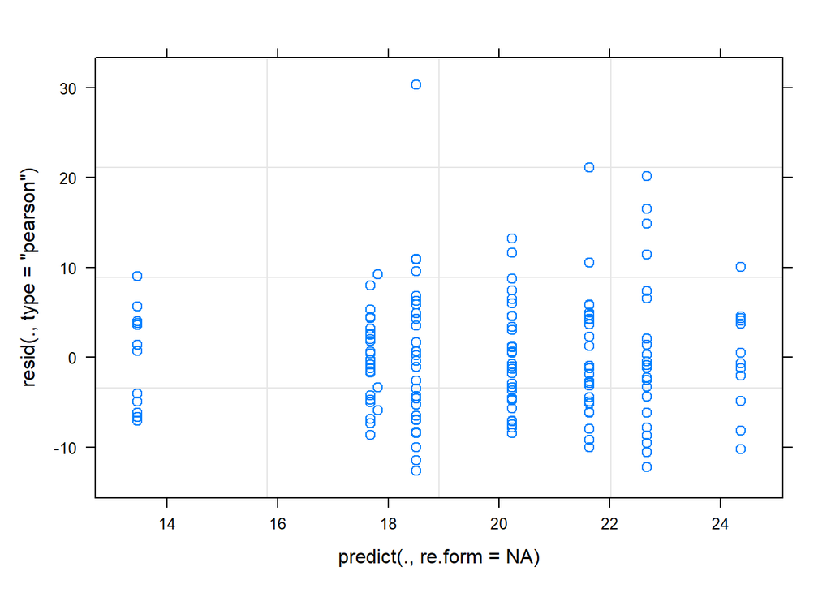

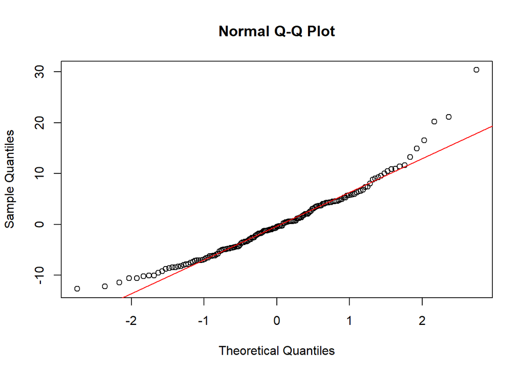

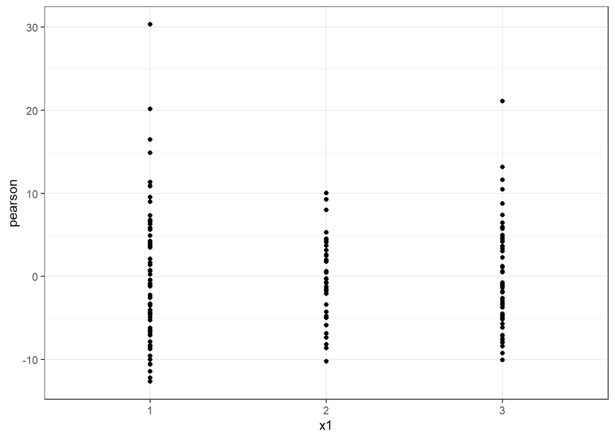

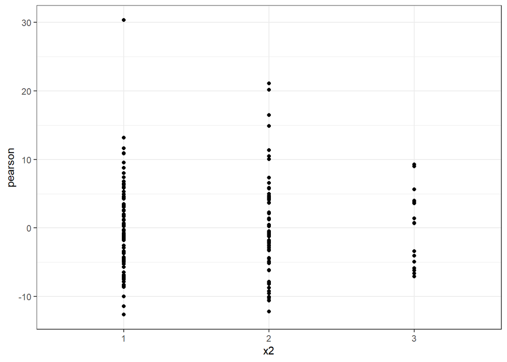

```r
rm(list = ls())
```